# Genomic Intervals in Bioconductor exercises

Rockefeller University, Bioinformatics Resource Centre

https://rockefelleruniversity.github.io/Bioconductor_Introduction/

## Working with Genomic Intervals

In this exercise we will work with some ChIP-seq peak calls for the Encode experiment [**ENCSR000ERN**](https://www.encodeproject.org/experiments/ENCSR000ERN/)

1. Install the GenomicRanges and rtracklayer package

```r
install.packages("BiocManager")
require(BiocManager)
install("GenomicRanges",update = FALSE)
install("rtracklayer",update = FALSE)
```

2. Read in the file **data/Myc_Ch12_1_withInput_Input_Ch12_peaks.xls** and create a GRanges object which includes values of fold_enrichment and - log10 pvalue provided in file.

```r
suppressPackageStartupMessages(library(rtracklayer))
suppressPackageStartupMessages(library(GenomicRanges))
"%in%" <- BiocGenerics::"%in%"
```

```r
library(rtracklayer)
library(GenomicRanges)
MYCpeaks <- read.delim("data/Myc_Ch12_1_withInput_Input_Ch12_peaks.xls",sep="\t",comment.char = "#")
MYCgranges <- GRanges(MYCpeaks$chr,IRanges(MYCpeaks$start,MYCpeaks$end),
                       FE=MYCpeaks$fold_enrichment,
                       minuslog10Pval=MYCpeaks$X.log10.pvalue.)
```

3. Create a boxplot of the fold enrichments in genomic intervals over every chromosome.

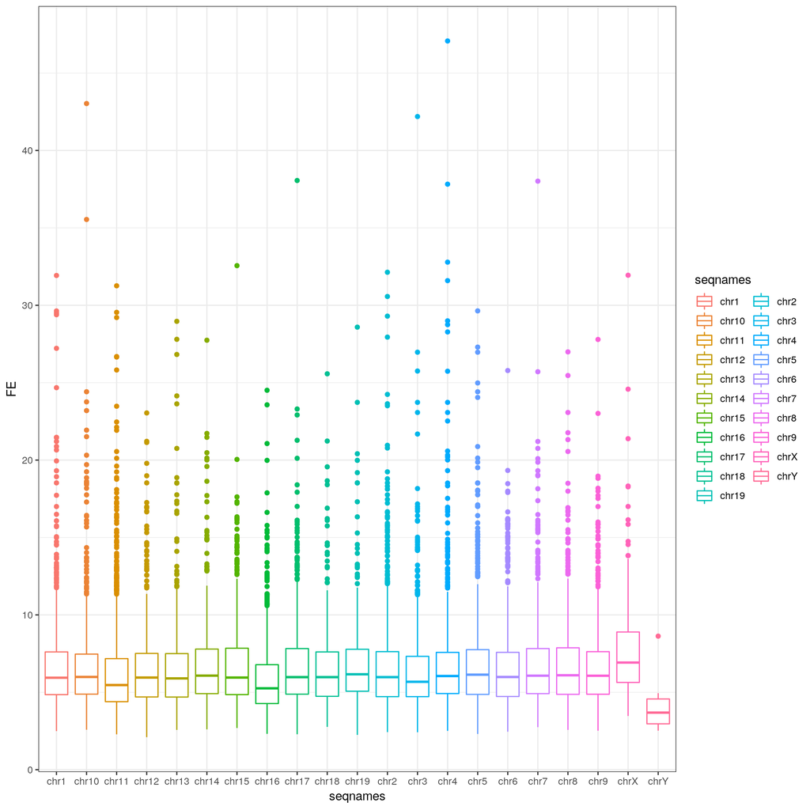

```r
MYCDF <- as.data.frame(MYCgranges)
library(ggplot2)
ggplot(MYCDF,aes(x=seqnames,y=FE,color=seqnames))+geom_boxplot()+theme_bw()
```

4. Create a GRanges object of genomic intervals on chromosome 1 with scores greater than 10 and pvalue less than 0.0001 and export as BED file **filteredMyc.bed**.

```r
MYCfilteredGRanges <- MYCgranges[MYCgranges$FE > 10 & MYCgranges$minuslog10Pval > -log10(0.0001)]
MYCfilteredGRangesChr1 <- MYCfilteredGRanges[seqnames(MYCfilteredGRanges) %in% "chr1"]
export.bed(MYCfilteredGRangesChr1,"filteredMyc.bed")
```

5. Read in TXT file of gene positions (containing contig - named as seqnames column-, genomic start and end) from the file **data/mm10_GenePosForIGV.txt** and export to a BED file **Genes.bed**

```r
IGVGenePositions <- read.delim("data/mm10_GenePosForIGV.txt",sep="\t")

genePos <- GRanges(IGVGenePositions$seqnames,
                   IRanges(IGVGenePositions$start,IGVGenePositions$end),
                   strand = IGVGenePositions$strand)

names(genePos) <- IGVGenePositions$gene_id
export.bed(genePos,con="Genes.bed")
```

6. Create a GRanges of the transcriptional start site positions of every gene (1bp exact TSS).

```r
tssPos <- resize(genePos,width = 1,fix = "start")
```

7. Extend this GRanges to be +/- 500 bp around the transciptional start sites.

```r
tssPosExt <- resize(tssPos,width = 1000,fix = "center")
```

8. Create a BED file (called **filteredMycOnTSS.bed**) of our Myc peaks from question 4 which overlap our new GRanges of +/- 500 bp around transciptional start sites.

```r
MYCforBED <- MYCfilteredGRangesChr1[MYCfilteredGRangesChr1 %over% tssPosExt]
export.bed(MYCforBED,con="filteredMycOnTSS.bed")
```

9. Import the generated BED files (**filteredMycOnTSS.bed**,**filteredMyc.bed**, **Genes.bed**) into IGV on mm10 genome.

Download the signal p-value bigwig from the encode portal for replicate 1 from experiment **ENCSR000ERN** and capture an image of bigWig signal over our BED intervals over igfbp2 gene.

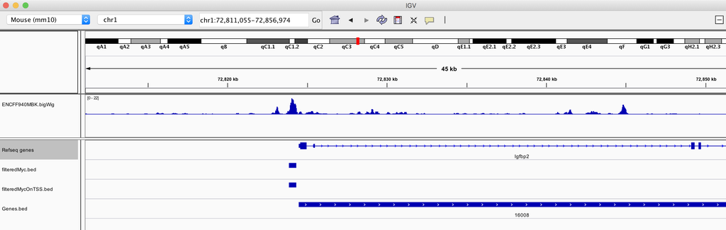

10. Import the **data/Myc_Ch12_1_withInput_Input_Ch12_summits.bed** BED file to a GRanges. The 5th column in file represents summit height.

```r
mySummits <- import.bed("data/Myc_Ch12_1_withInput_Input_Ch12_summits.bed")
```

11. Generate density plots of summit heights for summits overlapping and not overlapping our extended TSS positions

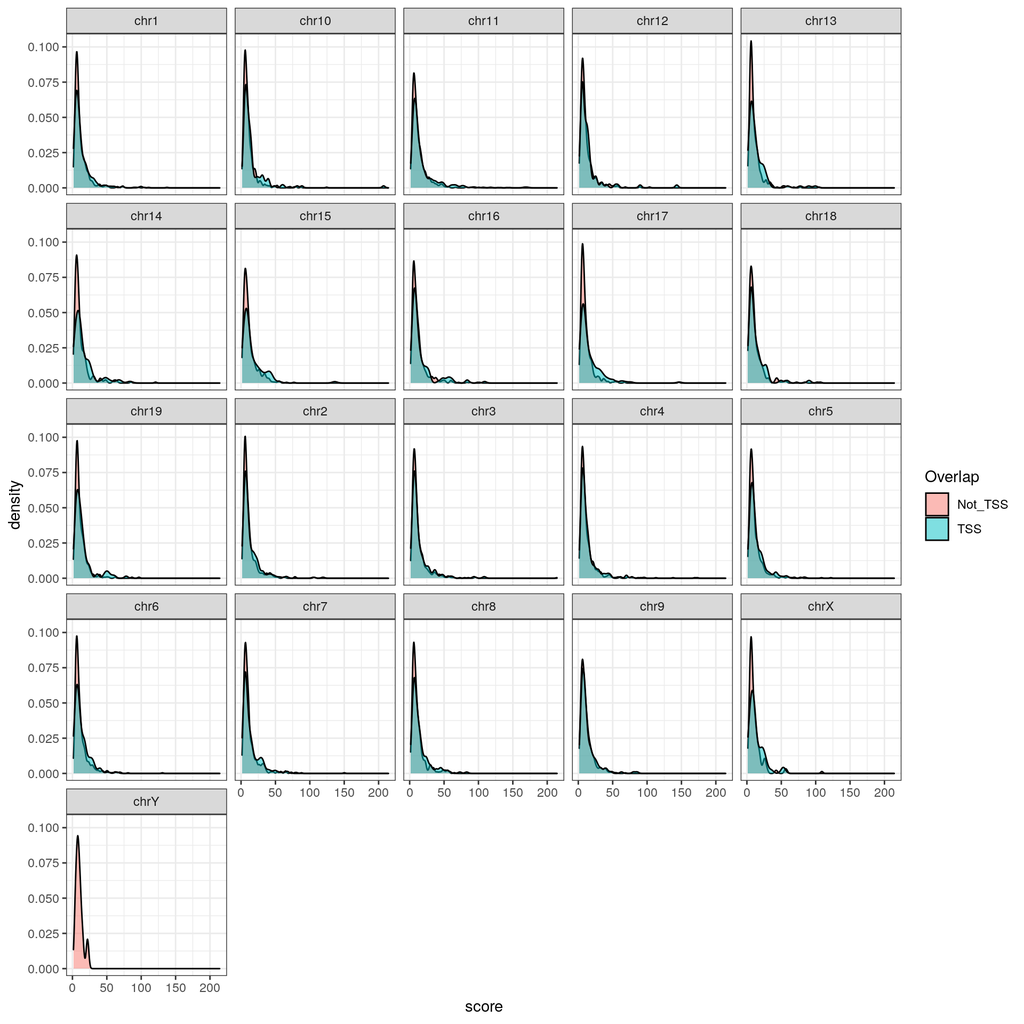

```r
mySummits$Overlap <- ifelse(mySummits %over% tssPosExt,"TSS","Not_TSS")
mySummitsDF <- as.data.frame(mySummits)
ggplot(mySummitsDF,aes(x=score,fill=Overlap))+geom_density(alpha=0.5)+
  facet_wrap(~seqnames)+theme_bw()
```

12. Filter the Summits GRanges to the top 500 ranked by the GRanges score column.

```r
orderSummits500 <- mySummits[order(mySummits$score,decreasing = TRUE)][1:500,]
```

13. Extend these top 500 Summits GRanges to 50bps around the centre of the GRanges intervals. Extract the sequences under the peaks and write to a file.

```r
centredSummits <- resize(orderSummits500,width = 50,fix="center")
library(BSgenome.Mmusculus.UCSC.mm10)
centredSummitsSeq <- getSeq(BSgenome.Mmusculus.UCSC.mm10,centredSummits)
writeXStringSet(centredSummitsSeq,filepath = "top500bySummit.fa")
```